# AS09_Wrap-Up

林綺薇 R09342008 新聞所碩一

2021/06/01

## 作業目的: Wrap Up

這次的作業是這個學期的總結。在過程中你可以自由的應用到各式學過的技巧，包含斷詞、字串處理、視覺化、文字探勘、長寬表格轉換、正規表達式、日期處理等。希望你會喜歡！

## 作業: Wrap Up

### 題目說明

我們準備了三個不同來源、不同主題、不同類型的資料，分別是韓國瑜與蔡英文演講稿、公投相關臉書政治社會廣告、美國大選新聞，詳細內容請參考[AS09資料說明](https://docs.google.com/spreadsheets/d/1k4K_Pd1s_lyjECO51gsBq-lbeQ_les1i-dZBt-MXU5Q/edit)。

### 作業要求

本作業以資料分析和資料視覺化為主，請自由選擇你有興趣的資料，並靈活運用這學期所學，寫出一篇分析文章。

- 寫出二到三個分析小結論
- 畫出二到三張圖
- 其中一個小結論要用到 topic modeling 或 collocation

### 作答區

先看一下資料長什麼樣子。

```r
# - 公投相關社會政治廣告 from 臉書
# - 美國大選相關新聞 from 幾間媒體
# - 韓國瑜蔡英文演講逐字稿 from 新聞/公開資料
library(tidyverse)
library(tidyr)
library(stringr)
library(jiebaR)
library(dplyr)
library(tidytext)
library(topicmodels)
library(lubridate)

### 公投相關社會政治廣告
df_fbad <- read_csv("data/AS09/fbad/results_gongtou_ad.csv")
df_fbad_demo <- read_csv("data/AS09/fbad/results_gongtou_demo.csv")
df_fbad_region <- read_csv("data/AS09/fbad/results_gongtou_region.csv")
```

### 作答區 - 你的程式碼和分析

### 公投大亂鬥，臉書廣告看什麼？

Facebook使用者眾多，根據過去的調查，許多台灣民眾接觸新知的管道為臉書，也因此臉書成了廣告所集之地。利用Facebook提供之公投相關廣告資料，可以了解熱門議題有哪些，以及你平常都吃了誰餵的廣告，一起來看，GOGO！

從下方折線圖可觀察出近年台灣Facebook廣告的高峰，分別為2020年一月的立法委員合併總統選舉、同年六月，同性婚姻支持團體也在臉書大量下各種廣告，宣傳同婚週年與「不再恐同計畫」，2021年在臉書下最多廣告的則是藻礁連署。

```
#> Storing counts in `nn`, as `n` already present in input
#> ℹ Use `name = "new_name"` to pick a new name.
```

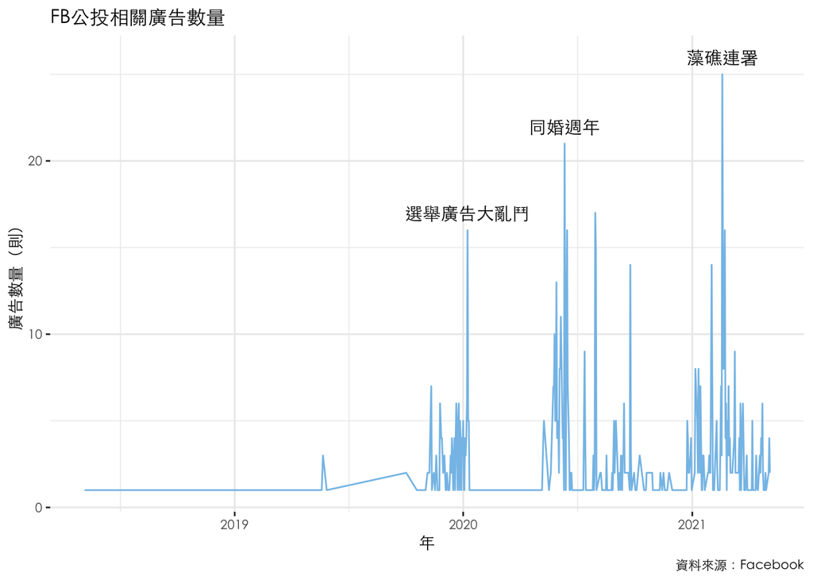

```r
#臉書公投廣告大爆量

df_fbad %>%
  mutate(time = as_date(df_fbad$ad_delivery_start_time)) %>%
  select(ad_creative_body,time) %>%
  group_by(time) %>%
  count(n = n()) %>%
  select(time,nn) %>%
  ggplot(aes(x = time, y= nn))+
  geom_line(color = "#85C1E9",size = 0.5)+
  annotate("text", x = ymd("2020-01-08") ,y=17, label= "選舉廣告大亂鬥",family="Heiti TC Light") +
  annotate("text", x = ymd("2020-06-11") ,y=22, label= "同婚週年",family="Heiti TC Light") +
  annotate("text", x = ymd("2021-02-18") ,y=26, label= "藻礁連署",family="Heiti TC Light") +
  ylab("廣告數量（則）")+
  xlab("年")+
  theme_bw()+
  theme(text=element_text(family="Heiti TC Light", size=10),
        legend.title=element_blank(),
        legend.position = "top",
        panel.border = element_blank())+
  labs(title = "FB公投相關廣告數量",
       caption = "資料來源：Facebook")
```

```r
# df_fbad %>%
#   mutate(time = as_date(df_fbad$ad_delivery_start_time)) %>%
#   select(ad_creative_body,time) %>%
#   group_by(time) %>%
#   count(n = n()) %>%
#   select(time,time_n = nn) %>%
#   arrange(desc(time_n)) %>%
#   head(10) %>%view

#2021-02-18 藻礁
#2020-06-11、2020-07-30 婚姻平權
#2020-01-08 朱智德、余筱菁選舉廣告
```

### 熱門議題佔據臉書，你follow到幾個？

近三年FB所呈現之公投相關廣告主題多圍繞民進黨的政策討論，包含大潭藻礁、同性婚姻、重啟核四、開放美豬進口等議題，各議題不論支持或反對方都善加利用臉書廣告投放以獲得曝光度。

此外，泰國學運與香港反送中運動也透過臉書廣告獲得一定的關注。

```r
### your code

cutter <- worker()
segment_not <- c("蔡英文", "台灣人", "傅崐萁","藻礁","台灣","臺灣","國民黨","民進黨","一個人","新竹市","新憲法","遊戲場")
new_user_word(cutter, segment_not)
```

```
#> [1] TRUE
```

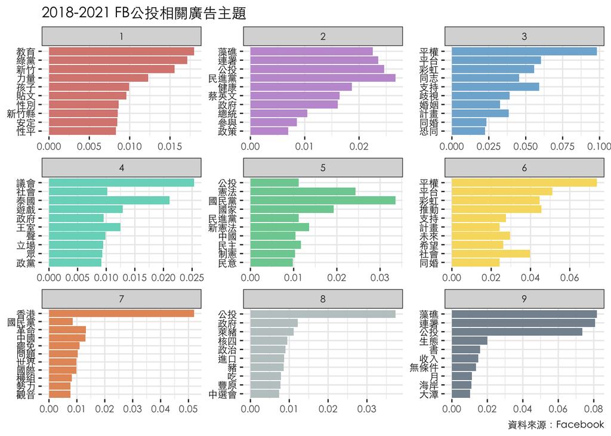

```r
stopWords <- readRDS("data/stopWords.rds")

unnested.df_fbad <- df_fbad %>%
  select(adlib_id,ad_creative_body) %>%
  mutate(word = purrr::map(ad_creative_body, function(x)segment(x, cutter))) %>%
  unnest(word) %>%
    filter(!is.na(word)) %>%
  filter(!(word %in% stopWords$word)) %>%
  filter(!str_detect(word, "[a-zA-Z0-9]+"))

doc_term_count <- unnested.df_fbad %>%
  filter(!word %in% c("我們","台灣","臺灣","年","一個","詳見","一起","人","卻","中","後")) %>%
  group_by(adlib_id,word) %>%
  filter(n() > 1) %>%
  ungroup() %>%
  count(adlib_id, word)

dtm <- doc_term_count %>%
         cast_dtm(adlib_id,word, n)

dtm_lda <- LDA(dtm, k = 9, control = list(seed = 1234))

dtm_topics <- tidy(dtm_lda, matrix = "beta")

top_terms <- dtm_topics %>%
    group_by(topic) %>%
    top_n(10, beta) %>%
    ungroup() %>%
    arrange(topic, -beta)

top_terms %>%
    mutate(term = reorder(term, beta)) %>%
    ggplot(aes(term, beta, fill = factor(topic))) +
    geom_col(show.legend = FALSE) +
    facet_wrap(~ topic, scales = "free") +
  scale_fill_manual(values = c("#D98880","#C39BD3","#7FB3D5","#76D7C4","#7DCEA0","#F7DC6F","#E59866","#BFC9CA","#85929E"))+
    coord_flip() +
  theme_bw()+
  xlab(NULL)+
  ylab(NULL)+
    theme(axis.text.y=element_text(colour="black", family="Heiti TC Light"),
          text=element_text(family="Heiti TC Light", size=10),
          legend.title=element_blank(),
        legend.position = "top",
        panel.border = element_blank()) +
  labs(title = "2018-2021 FB公投相關廣告主題",
       caption = "資料來源：Facebook")
```

### 誰是臉書的金主爸爸媽媽？

公投議題眾多，廣告花費不同，曝光度自然也不同。核四商轉公投花費14萬下廣告，提倡國民黨所支持的「以核養綠」概念，為資料中最多，其次是以反對LGBT權利運動為主要理念的基督教右翼政黨「安定力量」所投注的宣傳廣告，花費近八萬，實在是非常有錢。

其中也不乏藍綠兩大黨人物的廣告，民進黨柯建銘與國民黨江啟臣也分別花近2.5萬與1.5萬元台幣投注廣告，表達各自政治立場與主張。

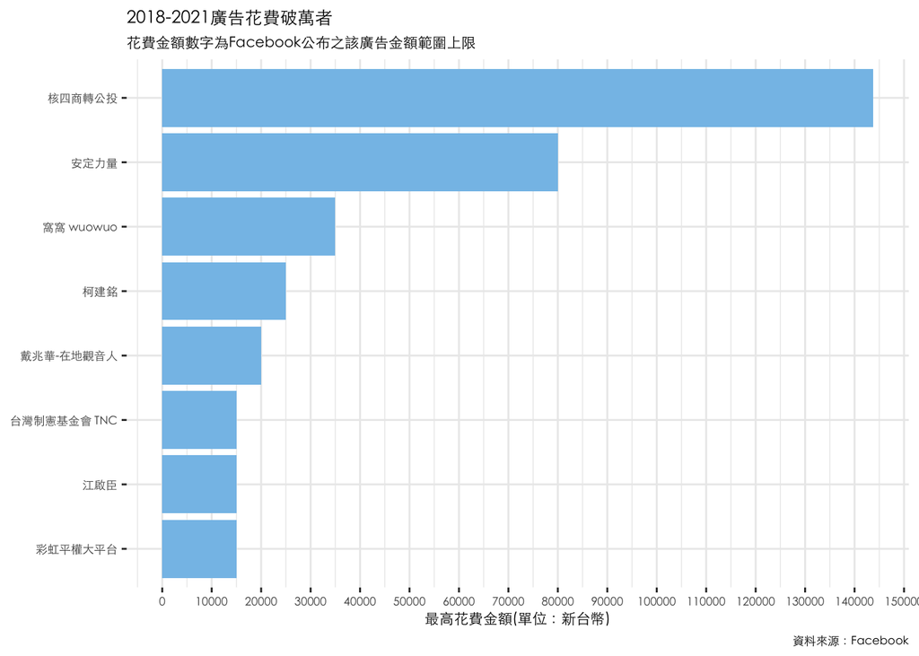

```r
TWD_df_fbad <- df_fbad %>%
  select(page_name,ad_creative_body,currency,spend_upper,adlib_id) %>%
  filter(currency == "TWD") %>%
  arrange(desc(spend_upper)) %>%
  head(10)

df_fbad %>%
  select(page_name,ad_creative_body,currency,spend_upper,adlib_id) %>%
  filter(currency == "USD") %>%
  arrange(desc(spend_upper)) %>%
  head(10) %>%
  mutate(spend_upper = spend_upper*30) %>%
  bind_rows(TWD_df_fbad) %>%
  arrange(desc(spend_upper)) %>%
  group_by(page_name) %>%
  summarise(all_spend_upper = sum(spend_upper)) %>%
  filter(all_spend_upper >10000) %>%
  ggplot(aes(x = reorder(page_name,as.numeric(all_spend_upper)) , y =as.numeric(all_spend_upper)))+
  ylab("最高花費金額(單位：新台幣)")+
  xlab(NULL)+
  scale_y_continuous(breaks = seq(0,150000,10000))+
  geom_col(fill = "#85C1E9",size = 5)+
  coord_flip()+
  theme_bw()+
  theme(text=element_text(family="Heiti TC Light", size=8),
        legend.title = element_blank(),
        panel.border = element_blank())+
  labs(title = "2018-2021廣告花費破萬者",
       subtitle = "花費金額數字為Facebook公布之該廣告金額範圍上限",
       caption = "資料來源：Facebook")
```

### 被哪一類的廣告K到，可以看出你的年齡

除了花多少錢，「對誰下廣告」、「是否瞭解受眾面貌」也是能否將廣告效益極大化的關鍵。Facebook提供的資料中，紀錄了每則廣告的受眾年齡與分布比例。

根據分析結果，18到44歲、較為年輕的臉書使用者，看到的廣告主題多為同性婚姻、泰國學運的討論，政治人物自我宣傳相關廣告較其他年齡層多元，除了民進黨，也出現綠黨、時代力量高鈺婷等不同政黨的候選人。

而主題為重啟核四、瘦肉精、反萊豬、國民黨主席江啟臣等廣告，從內文觀察，多為泛藍陣營的意見較多，主要針對45到64歲的臉書使用者投放，可看出與18到44歲所接受的廣告有所落差。至於藻礁公投連署的廣告，則是不分年齡層，存在感都很高。

```r
#哪個議題誰看最多、受眾？
all_df_fbad <- df_fbad %>%
  left_join(df_fbad_demo, by = "adlib_id") %>%
  left_join(df_fbad_region, by = "adlib_id") %>%
  rename(age_percentage = percentage.x,
         region_percentage = percentage.y)

#年輕人看什麼
young_head <- all_df_fbad %>%
  filter(age == "18-24"|age == "25-34"|age == "35-44") %>%
  select(ad_creative_body,age,gender,age_percentage,adlib_id) %>%
  arrange(desc(age_percentage)) %>%
  distinct(ad_creative_body,age_percentage,adlib_id) %>%
  head(500)
  #filter(age_percentage > 0.1)

cutter <- worker()
segment_not <- c("蔡英文", "台灣人", "傅崐萁","藻礁","台灣","臺灣","國民黨","民進黨","一個人","新竹市","新憲法","遊戲場","韓國瑜")
new_user_word(cutter, segment_not)
```

```
#> [1] TRUE
```

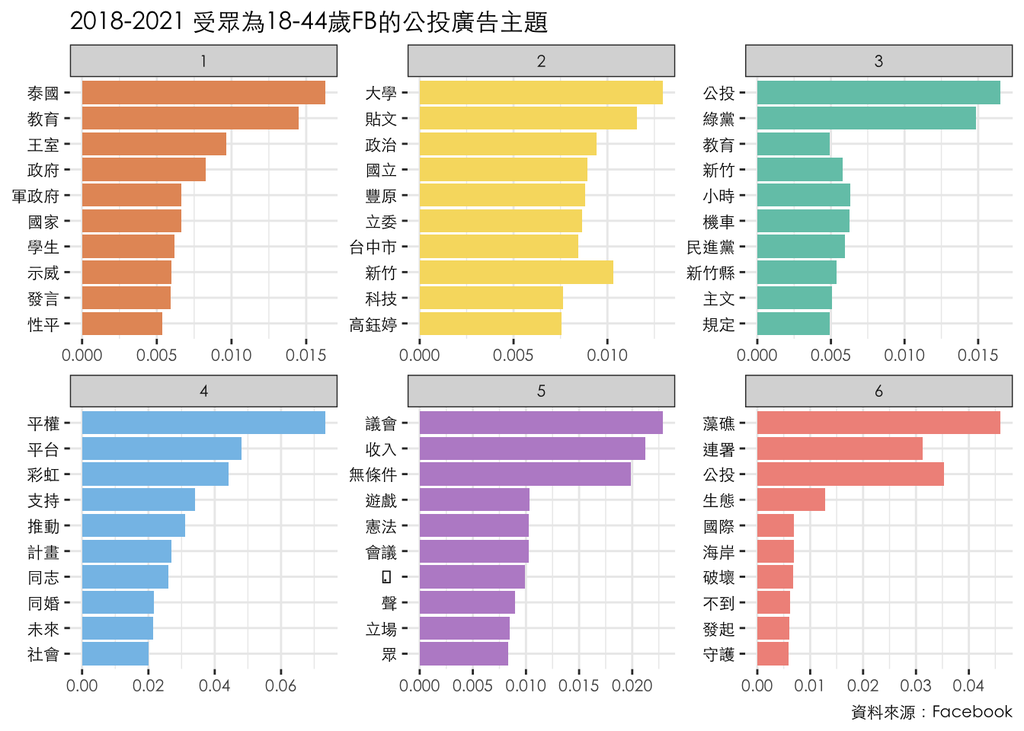

```r
stopWords <- readRDS("data/stopWords.rds")

unnested.young_head <- young_head %>%
  select(adlib_id,ad_creative_body) %>%
  mutate(word = purrr::map(ad_creative_body, function(x)segment(x, cutter))) %>%
  unnest(word) %>%
    filter(!is.na(word)) %>%
  filter(!(word %in% stopWords$word)) %>%
  filter(!str_detect(word, "[a-zA-Z0-9]+"))

doc_term_count1 <- unnested.young_head %>%
  filter(!word %in% c("我們","台灣","臺灣","年","一個","詳見","一起","人","卻","中","後")) %>%
  group_by(adlib_id,word) %>%
  filter(n() > 1) %>%
  ungroup() %>%
  count(adlib_id, word)

dtm1 <- doc_term_count1 %>%
         cast_dtm(adlib_id,word, n)

dtm_lda1 <- LDA(dtm1, k = 6, control = list(seed = 1234))

dtm_topics1 <- tidy(dtm_lda1, matrix = "beta")

top_terms1 <- dtm_topics1 %>%
    group_by(topic) %>%
    top_n(10, beta) %>%
    ungroup() %>%
    arrange(topic, -beta)

top_terms1 %>%
    mutate(term = reorder(term, beta)) %>%
    ggplot(aes(term, beta, fill = factor(topic))) +
    geom_col(show.legend = FALSE) +
    facet_wrap(~ topic, scales = "free") +
  scale_fill_manual(values = c("#E59866","#F7DC6F","#73C6B6","#85C1E9","#BB8FCE","#F1948A"))+
    coord_flip() +
  theme_bw()+
  xlab(NULL)+
  ylab(NULL)+
    theme(axis.text.y=element_text(colour="black", family="Heiti TC Light"),
          text=element_text(family="Heiti TC Light", size=10),
          legend.title=element_blank(),
        legend.position = "top",
        panel.border = element_blank()) +
  labs(title = "2018-2021 受眾為18-44歲FB的公投廣告主題",
       caption = "資料來源：Facebook")
```

```r
# young_tail <- all_df_fbad %>%
#   filter(age == "18-24"|age == "25-34"|age == "35-44") %>%
#   select(ad_creative_body,age,gender,age_percentage,adlib_id) %>%
#   arrange(desc(age_percentage)) %>%
#   distinct(ad_creative_body,age_percentage,adlib_id) %>%
#   tail(30)
#   #filter(age_percentage < 0.1)

#中生代看什麼
old_head <- all_df_fbad %>%
  filter(age == "45-54"|age == "55-64") %>%
  select(ad_creative_body,age,gender,age_percentage,adlib_id) %>%
  arrange(desc(age_percentage)) %>%
  distinct(ad_creative_body,age_percentage,adlib_id) %>%
  head(500)
  #filter(age_percentage > 0.1)

# old_tail <- all_df_fbad %>%
#   filter(age == "45-54"|age == "55-64") %>%
#   select(ad_creative_body,age,gender,age_percentage,adlib_id) %>%
#   arrange(desc(age_percentage)) %>%
#   distinct(ad_creative_body,age_percentage,adlib_id) %>%
#   tail(30)
#   #filter(age_percentage > 0.1)

cutter <- worker()
segment_not <- c("蔡英文", "台灣人", "傅崐萁","藻礁","台灣","臺灣","國民黨","民進黨","一個人","新竹市","新憲法","遊戲場","韓國瑜")
new_user_word(cutter, segment_not)
```

```
#> [1] TRUE
```

[figure not shown]

```r
stopWords <- readRDS("data/stopWords.rds")

unnested.old_head <- old_head %>%
  select(adlib_id,ad_creative_body) %>%
  mutate(word = purrr::map(ad_creative_body, function(x)segment(x, cutter))) %>%
  unnest(word) %>%
    filter(!is.na(word)) %>%
  filter(!(word %in% stopWords$word)) %>%
  filter(!str_detect(word, "[a-zA-Z0-9]+"))

doc_term_count2 <- unnested.old_head %>%
  filter(!word %in% c("我們","台灣","臺灣","年","一個","詳見","一起","人","卻","中","後")) %>%
  group_by(adlib_id,word) %>%
  filter(n() > 1) %>%
  ungroup() %>%
  count(adlib_id, word)

dtm2 <- doc_term_count2 %>%
         cast_dtm(adlib_id,word, n)

dtm_lda2 <- LDA(dtm2, k = 6, control = list(seed = 1234))

dtm_topics2 <- tidy(dtm_lda2, matrix = "beta")

top_terms2 <- dtm_topics2 %>%
    group_by(topic) %>%
    top_n(10, beta) %>%
    ungroup() %>%
    arrange(topic, -beta)

top_terms2 %>%
    mutate(term = reorder(term, beta)) %>%
    ggplot(aes(term, beta, fill = factor(topic))) +
    geom_col(show.legend = FALSE) +
    facet_wrap(~ topic, scales = "free") +
  scale_fill_manual(values = c("#E59866","#F7DC6F","#73C6B6","#85C1E9","#BB8FCE","#F1948A"))+
    coord_flip() +
  theme_bw()+
  xlab(NULL)+
  ylab(NULL)+
    theme(axis.text.y=element_text(colour="black", family="Heiti TC Light"),
          text=element_text(family="Heiti TC Light", size=10),
          legend.title=element_blank(),
        legend.position = "top",
        panel.border = element_blank()) +
  labs(title = "2018-2021 受眾為45-64歲FB的公投廣告主題",
       caption = "資料來源：Facebook")
```